# **Resolving Conflicting Cluster Validation Metrics**

## **ARI Stability Analysis Using Subsampling Bootstrap**

#### Author: Luis Rito Filipe

#### May, 2024

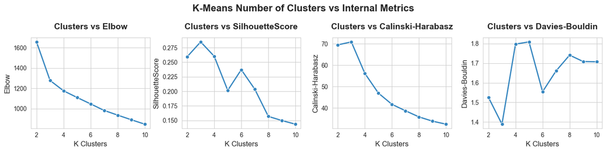

# Summary

Selecting the number of clusters is one of the most challenging aspects of unsupervised learning. Although several internal validation metrics are commonly used to guide this decision, they frequently recommend different clustering solutions, leaving the analyst without a clear criterion for selecting the final number of clusters.

This study presents a practical and reproducible workflow that combines established internal validation metrics with bootstrap stability analysis to support the selection of the final clustering solution. The methodology is demonstrated using both synthetic and real datasets and illustrates how clustering stability can provide additional evidence when the internal metrics disagree.

Another version of this publication is available ([link](https://luisritofilipe.github.io/data_science_learning/Resolving_conflicting_cluster_validation_metrics_with_code.html)) and includes the Python code used for data preparation, feature engineering, model training and evaluation, providing full reproducibility of the analysis. The present version focuses on the methodology, results and interpretation, omitting code excerpts to improve readability and visual presentation.

# About The Study

The objective of this study is not to propose a new clustering algorithm or a new cluster validity index. Instead, it presents a practical workflow that integrates well-established techniques into a systematic decision process for selecting the number of clusters.

Candidate clustering solutions are first identified using the internal validation metrics appropriate for each clustering algorithm. When multiple candidate values of k are obtained, bootstrap subsampling combined with the Adjusted Rand Index (ARI) is used to evaluate the reproducibility of each solution under repeated perturbations of the data. The workflow is intended to provide additional quantitative evidence for model selection while recognising that no automated procedure can universally determine the "correct" number of clusters.

Throughout the notebook, the methodology is validated on several synthetic and real datasets to illustrate both its strengths and its limitations in practical clustering applications.

# About The Dataset

The following study uses synthetic and real datasets publicly available. The synthetic datasets can be created through the scikit library, while the real datasets can be loaded from UCI Machine Learning Repository and the National Library of Medicine (see links below).

Dataset link: https://pmc.ncbi.nlm.nih.gov/articles/PMC12855581/

Dataset link: https://archive.ics.uci.edu/ml/machine-learning-databases/wine/wine.data

```python
import pandas as pd
import numpy as np
import matplotlib.pyplot as plt
import seaborn as sns
from sklearn.datasets import make_blobs, make_moons, make_circles, make_classification, load_wine
from sklearn.preprocessing import StandardScaler, LabelEncoder
from sklearn.metrics import silhouette_score, calinski_harabasz_score, davies_bouldin_score, adjusted_rand_score
from sklearn.cluster import KMeans, AgglomerativeClustering
from sklearn.mixture import GaussianMixture
from itertools import combinations
from sklearn.base import clone
from sklearn.metrics import adjusted_rand_score

pd.set_option('display.max_rows', None)
pd.set_option('display.max_columns', None)
pd.set_option('display.max_colwidth', None)

def compute_clustering_algos_internal_metrics(data, max_k):
    max_k = 3 if (max_k < 3) else max_k
    random_state = 42
    estimators = {
            "KMeans": KMeans,
            "AgglomerativeClustering": AgglomerativeClustering,
            "GaussianMixture": GaussianMixture
        }
    results = []
    for estimator_name, estimator_class in estimators.items():
        if estimator_name != "DBSCAN":
            for k in range(2, max_k + 1):
                if estimator_name == "KMeans":
                    estimator = estimator_class(n_clusters=k, random_state=random_state, n_init=10)
                elif estimator_name == "AgglomerativeClustering":
                    estimator = estimator_class(n_clusters=k, linkage="ward")
                elif estimator_name == "GaussianMixture":
                    estimator = estimator_class(n_components=k, covariance_type="tied", random_state=random_state)

                clusters = estimator.fit_predict(data)
                results.append({
                    "Algorithm": type(estimator).__name__,
                    "k": k,
                    "Elbow": estimator.inertia_ if isinstance(estimator, KMeans) else np.nan,
                    "SilhouetteScore": silhouette_score(data, clusters) if (not isinstance(estimator, GaussianMixture)) else np.nan,
                    "Calinski-Harabasz": calinski_harabasz_score(data, clusters) if (not isinstance(estimator, GaussianMixture)) else np.nan,
                    "Davies-Bouldin": davies_bouldin_score(data, clusters) if (not isinstance(estimator, GaussianMixture)) else np.nan,
                    "AIC": estimator.aic(data) if isinstance(estimator, GaussianMixture) else np.nan,
                    "BIC": estimator.bic(data) if isinstance(estimator, GaussianMixture) else np.nan
                })

    df_all = pd.DataFrame(results)
    candidate_k_by_algos_metrics = []
    kmeans = df_all[df_all["Algorithm"].eq("KMeans")].reset_index(drop=True)
    elbow_k = kmeans[(kmeans["Elbow"] - kmeans["Elbow"].shift(1)) > (kmeans["Elbow"].shift(1) - kmeans["Elbow"].shift(2))].iloc[0]["k"]
    silhouette_k = kmeans["k"].iloc[kmeans["SilhouetteScore"].idxmax()]
    calinski_k = kmeans["k"].iloc[kmeans["Calinski-Harabasz"].idxmax()]
    davies_k = kmeans["k"].iloc[kmeans["Davies-Bouldin"].idxmin()]
    candidate_k_by_algos_metrics.append({"Algorithm" : "KMeans", "Elbow_K" : elbow_k, "Silhouette_K" : silhouette_k, "Calinski_K" : calinski_k, "Davies_K" : davies_k})
    agglomerative = df_all[df_all["Algorithm"].eq("AgglomerativeClustering")].reset_index(drop=True)
    silhouette_k = agglomerative["k"].iloc[agglomerative["SilhouetteScore"].idxmax()]
    calinski_k = agglomerative["k"].iloc[agglomerative["Calinski-Harabasz"].idxmax()]
    davies_k = agglomerative["k"].iloc[agglomerative["Davies-Bouldin"].idxmin()]
    candidate_k_by_algos_metrics.append({"Algorithm" : "AgglomerativeClustering", "Silhouette_K" : silhouette_k, "Calinski_K" : calinski_k, "Davies_K" : davies_k})
    gmm = df_all[df_all["Algorithm"].eq("GaussianMixture")].reset_index(drop=True)
    aic_k = gmm["k"].iloc[gmm["AIC"].idxmin()]
    bic_k = gmm["k"].iloc[gmm["BIC"].idxmin()]
    candidate_k_by_algos_metrics.append({"Algorithm" : "GaussianMixture", "AIC_K" : aic_k, "BIC_K" : bic_k})

    return df_all, pd.DataFrame(candidate_k_by_algos_metrics)

def k_vs_elbow_vs_silhouettescore_vs_calinski_vs_davies(data):
    sns.set_style("whitegrid")
    n_subplots = len(data.columns) - 1
    fig, axes = plt.subplots(1, n_subplots, figsize=(14, 3.5))
    fig.suptitle("K-Means Number of Clusters vs Internal Metrics", y=0.98, fontsize=16, fontweight="bold" )
    for i in range(len(data.columns) - 1):
        sns.lineplot(
            x=data[data.columns[0]],
            y=data[data.columns[i + 1]],
            marker="o",
            linewidth=2,
            color=sns.color_palette("Blues", n_colors=5)[3],
            ax=axes[i]
        )
        axes[i].tick_params(axis='x', rotation=0)
        axes[i].set_title(f"Clusters vs {data.columns[i + 1]}", fontsize=14, fontweight="bold", pad=14)
        axes[i].set_xlabel("K Clusters", fontsize=12)
        axes[i].set_ylabel(f"{data.columns[i + 1]}", fontsize=12)
    plt.tight_layout()
    plt.show()
```

# Methodology

- The Clustering Problem
- Clustering Algorithms Considered
- Candidate Selection Using Internal Validation Metrics
- Selecting the Final Number of Clusters
- Discussion
- Conclusions

# The Clustering Problem

One of the fundamental challenges in unsupervised learning is determining the number of clusters that best represents the underlying structure of a dataset. Unlike supervised learning, clustering is performed without ground-truth labels, meaning there is no direct measure of prediction accuracy that can be used to validate the resulting partition. Consequently, selecting the appropriate number of clusters remains a model selection problem rather than a prediction problem.

Several internal validation metrics and evaluation techniques have been proposed to estimate the quality of a clustering solution. Among the most widely used are the Elbow Method, Silhouette Score, Calinski–Harabasz Index, Davies–Bouldin Index, and, for probabilistic models such as Gaussian Mixture Models, the Akaike Information Criterion (AIC) and Bayesian Information Criterion (BIC). Although these metrics often provide valuable guidance, they are based on different mathematical principles and therefore frequently recommend different numbers of clusters for the same dataset.

This disagreement presents a practical difficulty. When several candidate solutions appear plausible, there is often no objective criterion indicating which one should be preferred. In many real-world applications, practitioners rely on visual inspection, prior domain knowledge, or subjective interpretation to make the final decision. While these approaches may be appropriate in some situations, they reduce the reproducibility and objectivity of the clustering process.

The objective of this study is not to propose a universal solution to the cluster selection problem, nor to claim that a single "correct" number of clusters exists for every dataset. Instead, the goal is to introduce a systematic and reproducible methodology that provides additional evidence when internal validation metrics disagree. The proposed framework combines traditional internal validation metrics with bootstrap-based stability analysis, allowing competing clustering solutions to be evaluated not only by their internal quality but also by their reproducibility under repeated resampling of the data.

The methodology should therefore be viewed as a decision-support framework rather than an oracle for clustering. It cannot eliminate the need for interpretation or domain knowledge, but it can substantially reduce subjectivity by providing a defensible and transparent procedure for selecting among competing clustering solutions.

To illustrate the clustering problem, the figure below presents the same dataset in two different ways. The scatter plot on the left shows the observations without any label information, representing the typical scenario encountered in unsupervised learning. From this representation alone, determining the number of natural groups is not obvious. The scatter plot on the right displays the same observations coloured only to facilitate visual interpretation of the data distribution.

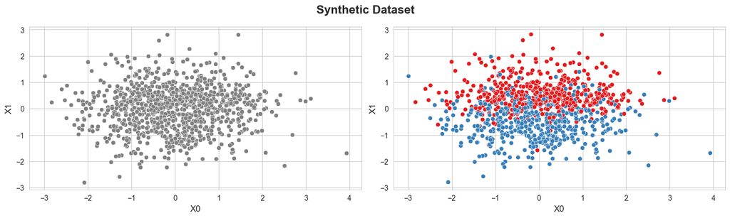

```python
X, y = make_classification(n_samples=1000, n_features=6, n_informative=2, n_redundant=2, n_clusters_per_class=2, random_state=42)
df = pd.DataFrame()
for i in range(X.shape[1]):
    df[f"X{i}"] = X[:,i]
def scatter_plot(data1, data2):
    sns.set_style("whitegrid")
    fig, axes = plt.subplots(1, 2, figsize=(14, 4.2))
    fig.suptitle("Synthetic Dataset", y=0.98, fontsize=16, fontweight="bold" )
    sns.scatterplot(
        x=df.X0,
        y=df.X1,
        color="Grey",
        legend=False,
        ax=axes[0]
    )
    sns.scatterplot(
        x=df.X0,
        y=df.X1,
        hue=data2,
        palette="Set1",
        legend=False,
        ax=axes[1]
    )

    for i in range(len(axes)):
        axes[i].set_xlabel("X0", fontsize=12)
        axes[i].set_ylabel("X1", fontsize=12)

    plt.tight_layout()
    plt.show()
scatter_plot(df, y)
```

The uncertainty observed in the unlabeled data is reflected by the internal validation metrics. As shown in the table below, different metrics recommend different numbers of clusters for exactly the same dataset. For the K-Means algorithm, the Elbow Method suggests four clusters, the Silhouette Score and Calinski–Harabasz Index recommend two clusters, and the Davies–Bouldin Index favours ten clusters. Similar disagreements can also be observed for Agglomerative Clustering and Gaussian Mixture Models.

```python
df_scaled = StandardScaler().fit_transform(df)
algos_internal_metrics, candidate_k = compute_clustering_algos_internal_metrics(df_scaled, 10)
candidate_k.style.hide(axis="index")
```

| Algorithm | Elbow_K | Silhouette_K | Calinski_K | Davies_K | AIC_K | BIC_K |
| --- | --- | --- | --- | --- | --- | --- |
| KMeans | 4.0 | 2.0 | 2.0 | 10.0 | NaN | NaN |
| AgglomerativeClustering | NaN | 2.0 | 2.0 | 10.0 | NaN | NaN |
| GaussianMixture | NaN | NaN | NaN | NaN | 10.0 | 5.0 |

# Clustering Algorithms Considered

To evaluate the proposed methodology, three widely used clustering algorithms are considered: K-Means, Agglomerative Clustering, and Gaussian Mixture Models (GMMs). These algorithms represent different approaches to partitioning data and require the number of clusters to be specified in advance. Because each algorithm relies on different assumptions about the underlying data distribution, they may produce different clustering solutions even when applied to the same dataset.

- K-Means is a centroid-based clustering algorithm that partitions observations into k groups by minimizing the within-cluster sum of squared distances. The algorithm iteratively assigns each observation to its nearest centroid and updates the centroid positions until convergence. It is computationally efficient and performs well when clusters are compact, approximately spherical, and have similar variances.

  Since K-Means minimizes Euclidean distance, it may struggle to identify clusters with irregular shapes or substantially different densities.
- Agglomerative Clustering is a hierarchical clustering algorithm. Instead of partitioning the data directly, it begins by treating each observation as an individual cluster and repeatedly merges the two closest clusters until the desired number of clusters is reached. The definition of "closest" depends on the selected linkage criterion, such as ward, complete, average, or single linkage.

  Unlike K-Means, Agglomerative Clustering is capable of identifying a wider range of cluster shapes, although its performance depends on the chosen linkage method.
- Gaussian Mixture Models assume that the data are generated from a mixture of Gaussian probability distributions. Instead of assigning each observation exclusively to one cluster, GMM estimates the probability that an observation belongs to each component. Final cluster assignments are then obtained by selecting the component with the highest posterior probability.

  Because GMM models clusters probabilistically, it can represent elliptical clusters and overlapping groups more effectively than K-Means. However, selecting an appropriate covariance structure and the number of mixture components is essential for obtaining meaningful results.

Although these algorithms differ substantially in their underlying assumptions, they all require the number of clusters to be specified before model fitting. Consequently, selecting an appropriate value of k becomes a critical step in the clustering process. To identify candidate values of k, several internal validation metrics are employed. These metrics are introduced in the following section.

# Candidate Selection Using Internal Validation Metrics

The next challenge is determining the number of clusters that best represents the structure of the data. Since clustering is an unsupervised learning task, no ground-truth labels are available to measure prediction accuracy. Instead, candidate clustering solutions are evaluated using internal validation metrics, which quantify desirable properties such as cluster compactness, separation, and model complexity.

- The Elbow Method evaluates the Within-Cluster Sum of Squares (WCSS), also known as inertia, as the number of clusters increases. As additional clusters are introduced, inertia decreases because observations are partitioned into increasingly smaller groups. The optimal number of clusters is often identified as the point where the rate of improvement begins to diminish, forming an "elbow" in the curve.
- The Silhouette Score measures how similar an observation is to its own cluster compared with neighbouring clusters. Values range from −1 to 1, where larger values indicate better-defined clusters. A high average Silhouette Score suggests that observations are well matched to their assigned cluster and poorly matched to neighbouring clusters.
- The Calinski–Harabasz Index evaluates the ratio between the dispersion of cluster centroids and the dispersion of observations within each cluster. Larger values generally indicate better-defined cluster structures.
- The Davies–Bouldin Index measures the average similarity between each cluster and its most similar neighbouring cluster. Lower values indicate better clustering solutions, reflecting compact clusters that are well separated from one another.
- Unlike centroid-based clustering algorithms, Gaussian Mixture Models estimate probabilistic distributions rather than deterministic partitions. Consequently, model selection is commonly performed using the Akaike Information Criterion (AIC) and the Bayesian Information Criterion (BIC), both of which balance model goodness-of-fit against model complexity. Smaller values indicate more parsimonious models.

Although these metrics provide valuable guidance, they frequently recommend different numbers of clusters for the same dataset. Rather than relying on a single metric, this study first identifies all candidate values of k suggested by the internal validation metrics. The final selection is then performed using the bootstrap-based stability analysis introduced in the next section.

# Selecting the Final Number of Clusters

Internal validation metrics frequently identify different candidate values for the optimal number of clusters. Since these metrics are based on different mathematical principles, disagreement between them should be expected rather than interpreted as an error. Consequently, selecting the final number of clusters requires additional evidence beyond the internal metrics alone.

The implementation proposed in this study consists of two sequential stages.

- First, the internal validation metrics are used to identify all plausible candidate values of k. Instead of selecting a single metric as the definitive criterion, every candidate suggested by the internal validation metrics is retained for further evaluation.
- The second stage evaluates the stability of each candidate clustering solution using bootstrap resampling. The underlying assumption is that a meaningful clustering structure should remain relatively consistent under small perturbations of the data. If a clustering solution changes substantially after randomly removing a small proportion of observations, its reliability may be questioned.
- For each candidate value of k, repeated bootstrap samples are generated from the original dataset. The clustering algorithm is fitted independently to each bootstrap sample, and the similarity between all pairs of clustering solutions is quantified using the Adjusted Rand Index (ARI). The mean Adjusted Rand Index (ARI) provides an estimate of the reproducibility of the clustering solution across repeated bootstrap samples. The Coefficient of Variation (CV) quantifies the relative variability of the ARI values with respect to their mean, allowing the different candidate clustering solutions to be compared on a common scale.
- The candidate clustering solutions are ranked according to their bootstrap stability. In practice, a high Mean ARI indicates that the clustering structure is reproducible across bootstrap samples, whereas a low CV indicates that this reproducibility is consistently maintained under repeated resampling.

The following table presents the results after the ARI subsampling bootstrap applied to the three clustering algorithms with the corresponding K candidates.

```python
def ari_subsampling_bootstrap( X, candidate_k, n_runs=100, sample_fraction=0.80 ):
    random_state = 42
    estimators = {
        "KMeans": KMeans,
        "AgglomerativeClustering": AgglomerativeClustering,
        "GaussianMixture": GaussianMixture
    }
    results = []
    scores = pd.DataFrame()
    k_n = int()
    for estimator_name, estimator_class in estimators.items():
        k_list = set(candidate_k[candidate_k["Algorithm"] == estimator_name].select_dtypes(include="number").iloc[0].dropna().astype(int))
        for k in sorted(k_list):#range(np.min(k_list), np.max(k_list) + 1)
            if estimator_name == "KMeans":
                estimator = estimator_class(n_clusters=k, random_state=random_state, n_init=10)
            elif estimator_name == "AgglomerativeClustering":
                estimator = estimator_class(n_clusters=k, linkage="ward")
            elif estimator_name == "GaussianMixture":
                estimator = estimator_class(n_components=k, covariance_type="tied", random_state=random_state)

            rng = np.random.default_rng(random_state)
            runs = []
            n = len(X)

            for _ in range(n_runs):
                idx = np.sort(
                    rng.choice(
                        n,
                        size=int(sample_fraction * n),
                        replace=False
                    )
                )

                X_sample = X[idx]
                model = clone(estimator)
                labels = model.fit_predict(X_sample)
                runs.append((idx, labels))

            ari_scores = []

            for (idx1, labels1), (idx2, labels2) in combinations(runs, 2):
                common = np.intersect1d(idx1, idx2)
                if len(common) < 20:
                    continue

                # positions of common observations
                pos1 = np.searchsorted(idx1, common)
                pos2 = np.searchsorted(idx2, common)

                ari = adjusted_rand_score(
                    labels1[pos1],
                    labels2[pos2]
                )

                ari_scores.append(ari)
            k_n += 1
            scores[f"K{k_n}"] = ari_scores
            ari_mean = np.mean(ari_scores)
            ari_std = np.std(ari_scores)
            ari_cv = np.round(100 * ari_std / ari_mean, 2)
            results.append({ "Algorithm" : type(model).__name__, "k" : k, "Mean ARI": ari_mean, "Std ARI": ari_std, "CV ARI": ari_cv })

    return pd.DataFrame(results), scores
cluster_selection, ari_scores = ari_subsampling_bootstrap( df_scaled, candidate_k, n_runs=100, sample_fraction=0.80 )
cluster_selection.style.hide(axis="index")
```

| Algorithm | k | Mean ARI | Std ARI | CV ARI |
| --- | --- | --- | --- | --- |
| KMeans | 2 | 0.961002 | 0.029206 | 3.040000 |
| KMeans | 4 | 0.782574 | 0.120728 | 15.430000 |
| KMeans | 10 | 0.557644 | 0.093810 | 16.820000 |
| AgglomerativeClustering | 2 | 0.470412 | 0.201366 | 42.810000 |
| AgglomerativeClustering | 10 | 0.403520 | 0.063135 | 15.650000 |
| GaussianMixture | 5 | 0.721799 | 0.226474 | 31.380000 |
| GaussianMixture | 10 | 0.528965 | 0.103136 | 19.500000 |

For K-Means, the Mean ARI reaches its highest value and the Coefficient of Variation (CV ARI) its lowest value at k=2. Together, these results indicate that the two-cluster solution is highly reproducible under repeated bootstrap resampling while exhibiting very low relative variability. In other words, the clustering structure remains largely unchanged despite small perturbations of the data, suggesting that the solution is both stable and consistent.

The candidate with k=4, identified by the Elbow Method, also presents reasonably good stability. However, its lower Mean ARI and considerably higher CV ARI indicate that the four-cluster solution is more sensitive to variations in the sampled observations than the two-cluster solution.

For Agglomerative Clustering, the bootstrap stability analysis paints a different picture. Although the Mean ARI is highest for k=2, it is substantially lower than that obtained by K-Means and is accompanied by a relatively large Coefficient of Variation, indicating considerable variability across bootstrap samples. Conversely, the solution with k=10 exhibits a lower Mean ARI but also a markedly lower CV ARI, suggesting greater consistency but weaker overall agreement between repeated clustering solutions. Consequently, neither candidate provides clear evidence of a stable clustering structure.

A similar trade-off is observed for the Gaussian Mixture Model. The candidate with k=5 achieves the highest Mean ARI, whereas the solution with k=10 presents a substantially lower Coefficient of Variation. As with Agglomerative Clustering, the bootstrap results do not identify a single, unequivocally superior solution, highlighting the importance of considering both reproducibility and relative variability when interpreting clustering stability.

Rather than replacing the internal validation metrics, the proposed methodology complements them by providing an additional criterion when several candidate solutions appear equally plausible.

It should be emphasised that this methodology is intended for clustering algorithms in which the number of clusters is specified a priori, such as K-Means, Agglomerative Clustering, and Gaussian Mixture Models. Density-based algorithms, such as DBSCAN and OPTICS, require a different validation strategy because the number of clusters emerges from the density structure of the data rather than being explicitly defined.

The following figure illustrates how the internal validation metrics evolve as the number of clusters increases for the K-Means algorithm. The candidate values of k correspond to the optima of the respective evaluation metrics.

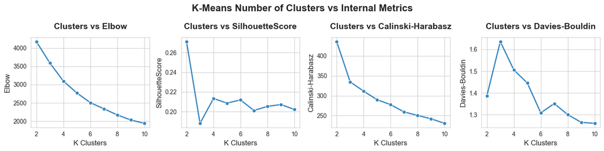

```python
k_vs_elbow_vs_silhouettescore_vs_calinski_vs_davies(algos_internal_metrics[algos_internal_metrics["Algorithm"].eq("KMeans")].reset_index(drop=True).drop(columns=["Algorithm", "AIC", "BIC"]))
```

The following scatter plot is a second example, now from a blood sample dataset for diabetes prognosis, a real dataset. Again, like the first example, two sub plots present the same dataset in two different ways, with the variables Glucose and Skin Thickness.

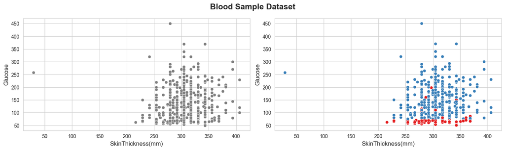

```python
df = pd.read_csv("dummy.csv")
def scatter_plot(data1):
    sns.set_style("whitegrid")
    fig, axes = plt.subplots(1, 2, figsize=(14, 4.2))
    fig.suptitle("Blood Sample Dataset", y=0.98, fontsize=16, fontweight="bold" )
    sns.scatterplot(
        x=data1["SkinThickness(mm)"],
        y=data1["Glucose"],
        color="Grey",
        legend=False,
        ax=axes[0]
    )
    sns.scatterplot(
        x=data1["SkinThickness(mm)"],
        y=data1["Glucose"],
        hue=data1["Type 2 Diabetic"],
        palette="Set1",
        legend=False,
        ax=axes[1]
    )
    for i in range(len(axes)):
        axes[i].set_xlabel("SkinThickness(mm)", fontsize=12)
        axes[i].set_ylabel("Glucose", fontsize=12)
    plt.tight_layout()
    plt.show()
scatter_plot(df)
```

```python
df_scaled = StandardScaler().fit_transform(df.drop(columns=["Type 2 Diabetic"]))
algos_internal_metrics, candidate_k = compute_clustering_algos_internal_metrics(df_scaled, 10)
candidate_k.style.hide(axis="index")
```

[output not shown]

The following table presents the results of the ARI subsampling bootstrap applied to the three clustering algorithms with the corresponding K candidates.

```python
cluster_selection, ari_scores = ari_subsampling_bootstrap( df_scaled, candidate_k, n_runs=100, sample_fraction=0.80 )
cluster_selection.style.hide(axis="index")
```

| Algorithm | k | Mean ARI | Std ARI | CV ARI |
| --- | --- | --- | --- | --- |
| KMeans | 2 | 0.973510 | 0.022295 | 2.290000 |
| KMeans | 4 | 0.766363 | 0.117641 | 15.350000 |
| KMeans | 10 | 0.557341 | 0.096873 | 17.380000 |
| AgglomerativeClustering | 9 | 0.512008 | 0.089545 | 17.490000 |
| AgglomerativeClustering | 10 | 0.508528 | 0.086763 | 17.060000 |
| GaussianMixture | 10 | 0.540526 | 0.145381 | 26.900000 |

The Diabetes Prognosis dataset provides a second example of the proposed methodology. Despite differences in the data distribution, the bootstrap stability analysis again identifies k=2 as the most reproducible clustering solution. Furthermore, the Coefficient of Variation of the ARI values is even lower than that obtained for the previous synthetic dataset, indicating that the two-cluster solution exhibits an exceptionally high degree of consistency under repeated bootstrap resampling.

This result should not be interpreted as evidence that two clusters are universally optimal. Rather, it demonstrates that the proposed methodology is capable of consistently identifying the most stable candidate among those suggested by the internal validation metrics.

The following figure illustrates how the internal validation metrics evolve as the number of clusters increases for the K-Means algorithm. The candidate values of k correspond to the optima of the respective evaluation metrics.

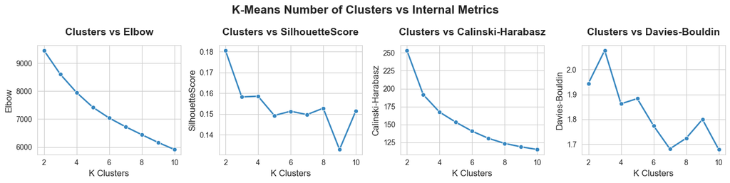

```python
k_vs_elbow_vs_silhouettescore_vs_calinski_vs_davies(algos_internal_metrics[algos_internal_metrics["Algorithm"].eq("KMeans")].reset_index(drop=True).drop(columns=["Algorithm", "AIC", "BIC"]))
```

The next figure presents a third example based on a real dataset. As in the previous examples, the two scatter plots display exactly the same observations in two different ways. The scatter plot on the left represents the unlabeled data, corresponding to the information typically available in an unsupervised learning problem. The scatter plot on the right displays the same observations coloured according to the dataset's class variable, which contains three unique values. Although these colours facilitate the visual interpretation of the data distribution, they should not be interpreted as the true clustering structure, since class labels and natural clusters are not necessarily equivalent.

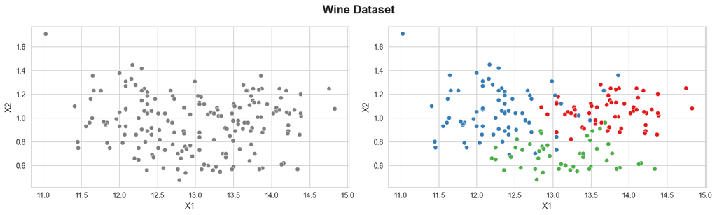

```python
X, y = load_wine(return_X_y=True)
def scatter_plot(data1, data2):
    sns.set_style("whitegrid")
    fig, axes = plt.subplots(1, 2, figsize=(14, 4.2))
    fig.suptitle("Wine Dataset", y=0.98, fontsize=16, fontweight="bold" )
    sns.scatterplot(
        x=data1[:,0],
        y=data1[:,10],
        color="Grey",
        legend=False,
        ax=axes[0]
    )
    sns.scatterplot(
        x=data1[:,0],
        y=data1[:,10],
        hue=data2,
        palette="Set1",
        legend=False,
        ax=axes[1]
    )
    for i in range(len(axes)):
        axes[i].set_xlabel("X1", fontsize=12)
        axes[i].set_ylabel("X2", fontsize=12)
    plt.tight_layout()
    plt.show()
scatter_plot(X, y)
```

In the following table, the different metrics recommend different numbers of clusters. For the K-Means algorithm, the Elbow Method suggests four clusters, the Silhouette Score, Calinski–Harabasz Index and the Davies–Bouldin Index favour three clusters. Similar disagreements can also be observed for Agglomerative Clustering and Gaussian Mixture Models.

```python
X_scaled = StandardScaler().fit_transform(X)
algos_internal_metrics, candidate_k = compute_clustering_algos_internal_metrics(X_scaled, 10)
candidate_k.style.hide(axis="index")
```

| Algorithm | Elbow_K | Silhouette_K | Calinski_K | Davies_K | AIC_K | BIC_K |
| --- | --- | --- | --- | --- | --- | --- |
| KMeans | 4.0 | 3.0 | 3.0 | 3.0 | NaN | NaN |
| AgglomerativeClustering | NaN | 3.0 | 3.0 | 2.0 | NaN | NaN |
| GaussianMixture | NaN | NaN | NaN | NaN | 10.0 | 4.0 |

The following table presents the results of the ARI subsampling bootstrap analysis for the three clustering algorithms using the candidate values of k previously identified by the internal validation metrics.

```python
cluster_selection, ari_scores = ari_subsampling_bootstrap( X_scaled, candidate_k, n_runs=100, sample_fraction=0.80 )
cluster_selection.style.hide(axis="index")
```

| Algorithm | k | Mean ARI | Std ARI | CV ARI |
| --- | --- | --- | --- | --- |
| KMeans | 3 | 0.964490 | 0.036916 | 3.830000 |
| KMeans | 4 | 0.803703 | 0.102025 | 12.690000 |
| AgglomerativeClustering | 2 | 0.644802 | 0.378212 | 58.660000 |
| AgglomerativeClustering | 3 | 0.829263 | 0.086190 | 10.390000 |
| GaussianMixture | 4 | 0.800609 | 0.075021 | 9.370000 |
| GaussianMixture | 10 | 0.494842 | 0.081118 | 16.390000 |

The results provide clear additional evidence for selecting the final number of clusters. For both K-Means and Agglomerative Clustering, the candidate with k=3 achieves a substantially higher Mean ARI while simultaneously exhibiting a considerably lower CV ARI than the competing candidate solutions. This indicates that the three-cluster partition is both highly reproducible and relatively insensitive to data perturbations introduced during bootstrap resampling.

For the Gaussian Mixture Model, the solution with k=4 also presents a markedly higher Mean ARI together with a lower CV ARI than the alternative with k=10, suggesting that the four-component model is considerably more stable under repeated resampling.

Taken together, these results illustrate how bootstrap stability analysis provides complementary evidence to the internal validation metrics, allowing competing candidate values of k to be evaluated according to the reproducibility of their clustering structures rather than relying solely on a single internal metric.

The following figure illustrates how the internal validation metrics evolve as the number of clusters increases for the K-Means algorithm. The candidate values of k correspond to the optima of the respective evaluation metrics.

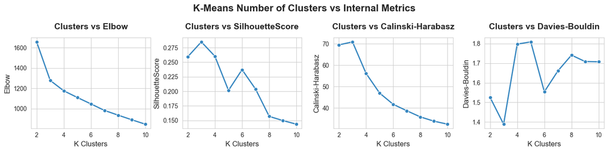

```python
k_vs_elbow_vs_silhouettescore_vs_calinski_vs_davies(algos_internal_metrics[algos_internal_metrics["Algorithm"].eq("KMeans")].reset_index(drop=True).drop(columns=["Algorithm", "AIC", "BIC"]))
```

The next figure presents a fourth and final example based on a synthetic dataset.

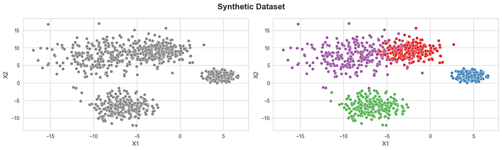

```python
X, y = make_blobs(n_samples=1000, centers=4, cluster_std=[1.7, 0.8, 1.8, 3.0], random_state=42)
def scatter_plot(data1, data2):
    sns.set_style("whitegrid")
    fig, axes = plt.subplots(1, 2, figsize=(14, 4.2))
    fig.suptitle("Synthetic Dataset", y=0.98, fontsize=16, fontweight="bold" )
    sns.scatterplot(
        x=data1[:,0],
        y=data1[:,1],
        color="Grey",
        legend=False,
        ax=axes[0]
    )
    sns.scatterplot(
        x=data1[:,0],
        y=data1[:,1],
        hue=data2,
        palette="Set1",
        legend=False,
        ax=axes[1]
    )
    for i in range(len(axes)):
        axes[i].set_xlabel("X1", fontsize=12)
        axes[i].set_ylabel("X2", fontsize=12)
    plt.tight_layout()
    plt.show()
scatter_plot(X, y)
```

```python
X_scaled = StandardScaler().fit_transform(X)
algos_internal_metrics, candidate_k = compute_clustering_algos_internal_metrics(X_scaled, 10)
candidate_k.style.hide(axis="index")
```

[output not shown]

The following table highlights an important aspect of the proposed workflow. In the previous examples, the number of clusters suggested by the Silhouette Score for the K-Means algorithm consistently exhibited the highest Mean ARI and the lowest CV ARI. Based on those examples alone, one might incorrectly conclude that the Silhouette Score always identifies the clustering solution that is most stable under data perturbation.

This final example demonstrates that such a conclusion would be misleading. Here, the clustering solution exhibiting the highest reproducibility under bootstrap resampling is not the one recommended by the Silhouette Score, but rather the candidate identified by the Davies–Bouldin Index. This example reinforces the motivation for combining internal validation metrics with bootstrap stability analysis, showing that no single internal metric can be expected to consistently identify the most stable clustering solution across different datasets.

```python
cluster_selection, ari_scores = ari_subsampling_bootstrap( X_scaled, candidate_k, n_runs=100, sample_fraction=0.80 )
cluster_selection.style.hide(axis="index")
```

| Algorithm | k | Mean ARI | Std ARI | CV ARI |
| --- | --- | --- | --- | --- |
| KMeans | 3 | 0.996998 | 0.003578 | 0.360000 |
| KMeans | 4 | 0.995365 | 0.005386 | 0.540000 |
| AgglomerativeClustering | 3 | 0.996606 | 0.005074 | 0.510000 |
| GaussianMixture | 9 | 0.762499 | 0.063397 | 8.310000 |
| GaussianMixture | 10 | 0.771333 | 0.057082 | 7.400000 |

The following figure illustrates how the internal validation metrics evolve as the number of clusters increases for the K-Means algorithm. The candidate values of k correspond to the optima of the respective evaluation metrics.

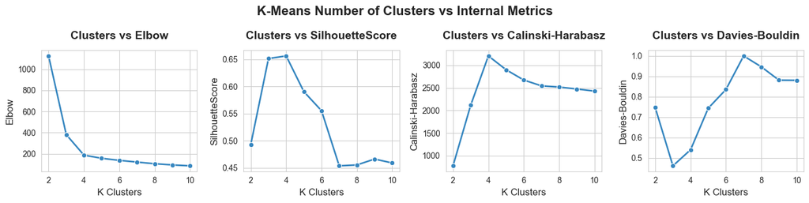

```python
k_vs_elbow_vs_silhouettescore_vs_calinski_vs_davies(algos_internal_metrics[algos_internal_metrics["Algorithm"].eq("KMeans")].reset_index(drop=True).drop(columns=["Algorithm", "AIC", "BIC"]))
```

# Discussion

This study demonstrates that selecting the number of clusters cannot always be based on a single internal validation metric. Across both synthetic and real datasets, the Elbow Method, Silhouette Score, Davies–Bouldin Index, and, for Gaussian Mixture Models, the AIC and BIC frequently recommended different candidate values for the number of clusters. This highlights one of the main practical challenges of unsupervised learning: different validation criteria often capture different characteristics of the data.

The ARI subsampling bootstrap analysis proved to be a useful complementary tool for comparing competing candidate solutions. Rather than attempting to identify the "true" number of clusters, the procedure evaluates the reproducibility of the clustering structure under repeated perturbations of the data. Solutions exhibiting a high Mean ARI together with a low Coefficient of Variation consistently demonstrated greater robustness to data perturbation.

It should be emphasized that clustering stability should not replace domain knowledge or the interpretation of the resulting clusters. Instead, it provides additional quantitative evidence that can support the final selection when internal validation metrics disagree.

# Conclusions

This study presented a practical workflow for selecting the number of clusters by combining established internal validation metrics with bootstrap stability analysis. The proposed workflow does not introduce a new clustering algorithm or a new cluster validity index. Instead, it integrates well-established techniques into a reproducible decision process for evaluating competing candidate clustering solutions.

The experimental results indicate that bootstrap stability analysis can provide valuable additional evidence for selecting among candidate values of k, particularly when the internal validation metrics provide conflicting recommendations. At the same time, the experiments also illustrate that no automated procedure can universally determine the "correct" number of clusters. The final decision should always consider the characteristics of the dataset, the intended application, and the interpretability of the resulting clustering solution.

The workflow presented in this study aims to provide a systematic and reproducible approach to clustering model selection, reducing reliance on subjective interpretation while acknowledging the inherent uncertainty of unsupervised learning.